# Create Dataset

```r
#setwd('/afs/inf.ed.ac.uk/user/s17/s1725186/Documents/PhD-Models/FirstPUModel/RMarkdowns')

library(tidyverse) ; library(reshape2) ; library(glue) ; library(plotly) ; library(dendextend)
library(RColorBrewer) ; library(viridis) ; require(gridExtra) ; library(GGally)
suppressWarnings(suppressMessages(library(WGCNA)))
library(expss) ; library(knitr)
library(polycor)
library(foreach) ; library(doParallel)
```

### Dataset

The dataset corresponds to the processing pipeline found in Preprocessing/Gandal/AllRegions/RMarkdowns/20_02_27_*.html, which has been copied to the Data folder in the BiasCorrection folder

```r
# Gandal dataset
load('./../Data/preprocessed_data.RData')
datExpr = datExpr %>% data.frame
DE_info = DE_info %>% data.frame


# GO Neuronal annotations
GO_annotations = read.csv('./../Data/genes_GO_annotations.csv')
GO_neuronal = GO_annotations %>% filter(grepl('neuron', go_term)) %>%
              mutate('ID'=as.character(ensembl_gene_id)) %>%
              dplyr::select(-ensembl_gene_id) %>% distinct(ID) %>%
              mutate('Neuronal'=1)


# SFARI Genes
SFARI_genes = read_csv('./../Data/SFARI_genes_08-29-2019_with_ensembl_IDs.csv')
SFARI_genes = SFARI_genes[!duplicated(SFARI_genes$ID) & !is.na(SFARI_genes$ID),]


# Clusterings
clusterings = read_csv('./../Data/clusters.csv')


# Update DE_info with SFARI and Neuronal information
genes_info = DE_info %>% mutate('ID'=rownames(.)) %>% left_join(SFARI_genes, by='ID') %>%
  mutate(`gene-score`=ifelse(is.na(`gene-score`), 'None', `gene-score`)) %>%
  left_join(GO_neuronal, by='ID') %>% left_join(clusterings, by='ID') %>%
  mutate(Neuronal=ifelse(is.na(Neuronal), 0, Neuronal)) %>%
  mutate(gene.score=ifelse(`gene-score`=='None' & Neuronal==1, 'Neuronal', `gene-score`),
         significant=padj<0.05 & !is.na(padj))


rm(DE_info, GO_annotations, dds)
```

The clusterings files include the modules obtained from WGCNA with many parameters. In previous experiments (Preprocessing/Gandal/AllRegions/RMarkdowns/20_02_27_WGCNA_modules_EA.html) we found Dynamic Hybrid to be the best option, so that’s the clustering we are going to use here as well.

- I’m going to use a version of the Dynamic Hybrid algorithm where similar modules have been merged together to have a simpler model with less parameters

```r
clustering_selected = 'DynamicHybridMergedSmall'
genes_info$Module = genes_info[,clustering_selected]
```

# Exploratory Analysis of modules

## Relate modules to external clinical traits

### Quantifying module-trait associations

In the WGCNA documentation they use Pearson correlation to calculate correlations, I think all of their variables were continuous. Since I have categorical variables I’m going to use the `hetcor` function, that calculates Pearson, polyserial or polychoric correlations depending on the type of variables involved.

- I’m not sure how the corPvalueStudent function calculates the p-values and I cannot find any documentation…
- Compared correlations using Pearson correlation and with hetcor and they are very similar, but a bit more extreme with hetcor. The same thing happens with the p-values.

```r
datTraits = datMeta %>% dplyr::select(Diagnosis, Region, Sex, Age, PMI, RNAExtractionBatch) %>%
            dplyr::rename('ExtractionBatch' = RNAExtractionBatch)

# Recalculate MEs with color labels
ME_object = datExpr %>% t %>% moduleEigengenes(colors = genes_info[,clustering_selected])
MEs = orderMEs(ME_object$eigengenes)

# Calculate correlation between eigengenes and the traits and their p-values
moduleTraitCor = MEs %>% apply(2, function(x) hetcor(x, datTraits, ML=TRUE)$correlations[1,-1]) %>% t
rownames(moduleTraitCor) = colnames(MEs)
colnames(moduleTraitCor) = colnames(datTraits)

# In case there are any NAs
if(sum(!complete.cases(moduleTraitCor))>0){
  print(paste0(sum(is.na(moduleTraitCor)),' correlation(s) could not be calculated'))

  # Calculate the correlation tha failed with hetcor()
  missing_modules = rownames(moduleTraitCor)[is.na(moduleTraitCor[,1])]

  for(m in missing_modules){
    cat(paste0('Correcting Module-Diagnosis correlation for Module ', m))
    moduleTraitCor[m,'Diagnosis'] = polyserial(MEs[,m], datTraits$Diagnosis)
  }
}

# Calculate p-values
moduleTraitPvalue = corPvalueStudent(moduleTraitCor, nrow(datExpr))

# Create text matrix for the Heatmap
textMatrix = paste0(signif(moduleTraitCor, 2), ' (', signif(moduleTraitPvalue, 1), ')')
dim(textMatrix) = dim(moduleTraitCor)

rm(ME_object)
```

Modules have very strong correlations with Diagnosis and not much else

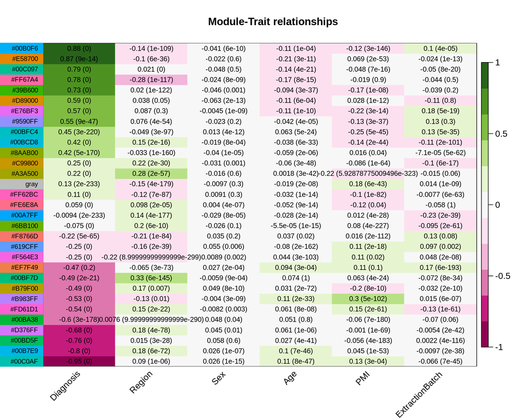

```r
# Sort moduleTraitCor by Diagnosis
moduleTraitCor = moduleTraitCor[order(moduleTraitCor[,1], decreasing=TRUE),]
moduleTraitPvalue = moduleTraitPvalue[order(moduleTraitCor[,1], decreasing=TRUE),]

# Create text matrix for the Heatmap
textMatrix = paste0(signif(moduleTraitCor, 2), ' (', signif(moduleTraitPvalue, 1), ')')
dim(textMatrix) = dim(moduleTraitCor)


labeledHeatmap(Matrix = moduleTraitCor, xLabels = names(datTraits), yLabels =  gsub('ME','',rownames(moduleTraitCor)),
               yColorWidth=0, colors = brewer.pal(11,'PiYG'), bg.lab.y = gsub('ME','',rownames(moduleTraitCor)),
               textMatrix = textMatrix, setStdMargins = FALSE, cex.text = 0.8, cex.lab.y = 0.75, zlim = c(-1,1),
               main = paste('Module-Trait relationships'))
```

```r
diagnosis_cor = data.frame('Module' = gsub('ME','',rownames(moduleTraitCor)),
                           'MTcor' = moduleTraitCor[,'Diagnosis'],
                           'MTpval' = moduleTraitPvalue[,'Diagnosis'])

genes_info = genes_info %>% left_join(diagnosis_cor, by='Module')

rm(moduleTraitCor, moduleTraitPvalue, datTraits, textMatrix, diagnosis_cor)
```

## Gene Significance and Module Membership

This is the information that will be included into the model

```r
# It's more efficient to iterate the correlations one by one, otherwise it calculates correlations between the eigengenes and also between the genes, which we don't need

# Check if MM information already exists and if not, calculate it
if(file.exists(paste0('./../Data/dataset_', clustering_selected, '.csv'))){

  dataset = read.csv(paste0('./../Data/dataset_', clustering_selected, '.csv'))
  dataset$Module = dataset[,clustering_selected]

} else {

  ############# 1. Calculate Gene Significance
  GS_info = data.frame('ID' = rownames(datExpr),
                       'GS' = datExpr %>% apply(1, function(x) hetcor(x, datMeta$Diagnosis)$correlations[1,2])) %>%
            mutate('GSpval' = corPvalueStudent(GS, ncol(datExpr)))

  #############  2. Calculate Module Membership

  #setup parallel backend to use many processors
  cores = detectCores()
  cl = makeCluster(cores-1)
  registerDoParallel(cl)

  # Create matrix with MM by gene
  MM = foreach(i=1:nrow(datExpr), .combine=rbind) %dopar% {
    library(polycor)
    tempMatrix = apply(MEs, 2, function(x) hetcor(as.numeric(datExpr[i,]), x)$correlations[1,2])
    tempMatrix
  }

  # Stop clusters
  stopCluster(cl)

  rownames(MM) = rownames(datExpr)
  colnames(MM) = paste0('MM',gsub('ME','',colnames(MEs)))

  # Calculate p-values
  MMpval = MM %>% corPvalueStudent(ncol(datExpr)) %>% as.data.frame
  colnames(MMpval) = paste0('MMpval', gsub('ME','',colnames(MEs)))

  MM = MM %>% as.data.frame %>% mutate(ID = rownames(.))
  MMpval = MMpval %>% as.data.frame %>% mutate(ID = rownames(.))

  # Join and save results
  dataset = genes_info %>% dplyr::select(ID, `gene-score`, clustering_selected, MTcor, MTpval) %>%
            left_join(GS_info, by='ID') %>%
            left_join(MM, by='ID') %>%
            left_join(MMpval, by='ID')

  write.csv(dataset, file = paste0('./../Data/dataset_', clustering_selected, '.csv'), row.names = FALSE)

  rm(cores, cl)

}

GS_missing = dataset$ID[is.na(dataset$GS)] %>% as.character

if(length(GS_missing)>0){

  print(paste0(length(GS_missing),' correlations between genes and Diagnosis could not be calculated, ',
               'calculating them with the polyserial function'))

  for(g in GS_missing){
    dataset$GS[dataset$ID == g] = polyserial(as.numeric(datExpr[g,]), datMeta$Diagnosis)
  }

}
```

```
## [1] "2 correlations between genes and Diagnosis could not be calculated, calculating them with the polyserial function"
```

```r
rm(GS_missing)
```

# Create and save dataset

```r
dataset = dataset %>% dplyr::select(-matches(clustering_selected))

dataset %>% head(5) %>% t %>% kable(caption = '(Transposed) features and their values for the first rows of dataset')
```

(Transposed) features and their values for the first rows of dataset

|  | 1 | 2 | 3 | 4 | 5 |
| --- | --- | --- | --- | --- | --- |
| ID | ENSG00000000003 | ENSG00000000419 | ENSG00000000457 | ENSG00000000460 | ENSG00000000938 |
| gene.score | None | None | None | None | None |
| MTcor | 0.5704012 | 0.2525473 | -0.9514071 | -0.8039747 | 0.8771832 |
| MTpval | 0 | 0 | 0 | 0 | 0 |
| GS | 0.3866600 | 0.0319742 | -0.3948272 | -0.2425891 | 0.4206897 |
| GSpval | 0.0003958804 | 0.7782832791 | 0.0002897603 | 0.0301486486 | 0.0001021298 |
| MM.B79F00 | -0.34215361 | -0.06859934 | 0.18223836 | -0.02031216 | 0.04018780 |
| MM.FE6E8A | -0.08150131 | -0.24064562 | -0.03148836 | -0.11492643 | 0.25329964 |
| MM.00BF7D | -0.1457984 | -0.1570793 | 0.2895552 | 0.2146387 | -0.1582971 |
| MM.D376FF | -0.1558365 | -0.3275203 | 0.2216473 | 0.1076922 | -0.1267206 |
| MM.00B7E9 | -0.2706076 | 0.1086927 | 0.2716955 | 0.3287583 | -0.1127668 |
| MM.00BD5F | -0.21031374 | -0.07391319 | 0.15884102 | 0.11647218 | -0.11654570 |
| MM.00BA38 | -0.20730963 | -0.20635820 | 0.14230634 | -0.01379535 | -0.24078920 |
| MM.FF62BC | 0.08818712 | -0.07296581 | -0.05364792 | -0.15198336 | 0.02089353 |
| MM.619CFF | -0.02780088 | -0.38882258 | 0.15295416 | 0.06990999 | -0.03113389 |
| MM.EF7F49 | -0.07434952 | -0.39533831 | 0.18574051 | -0.18532769 | -0.05110092 |
| MM.F8766D | 0.03205664 | -0.27552466 | -0.04739364 | -0.25553236 | -0.07174510 |
| MM.00C0AF | -0.3240023 | -0.0804812 | 0.4041119 | 0.1597938 | -0.4479131 |
| MM.B983FF | -0.13984232 | -0.13063988 | 0.29551959 | 0.08521686 | -0.32617942 |
| MM.F564E3 | -0.047256201 | -0.002151736 | 0.166606571 | -0.021824822 | -0.213475044 |
| MM.FD61D1 | -0.2102549 | 0.3544128 | 0.2690348 | 0.4502318 | -0.4636712 |
| MM.8AAB00 | 0.19517898 | 0.38203301 | -0.04717862 | 0.24441002 | -0.12381708 |
| MM.C99800 | 0.14630147 | 0.50085500 | -0.08926249 | 0.35734997 | -0.09120000 |
| MM.00BFC4 | -0.04198165 | 0.02238519 | -0.06181007 | -0.04955634 | 0.29411679 |
| MMgray | -0.22273016 | 0.03279002 | 0.11748544 | 0.27621848 | -0.10383201 |
| MM.E58700 | 0.14367115 | -0.01572201 | -0.34007238 | -0.27244789 | 0.12150780 |
| MM.FF67A4 | 0.2300837 | -0.1215257 | -0.1906585 | -0.3770794 | 0.1655206 |
| MM.00A7FF | -0.1508215 | 0.1640578 | 0.0744979 | 0.1972789 | -0.1825727 |
| MM.6BB100 | -0.14128950 | 0.04419752 | 0.06250344 | 0.24177793 | 0.07991980 |
| MM.00C097 | 0.14504413 | 0.02575275 | -0.23829518 | -0.09539647 | 0.29896397 |
| MM.39B600 | 0.32926114 | -0.07593457 | -0.30952348 | -0.39580982 | 0.25798937 |
| MM.9590FF | 0.2281574 | 0.1383876 | -0.2008810 | 0.0354509 | 0.3490105 |
| MM.A3A500 | 0.20085478 | 0.08535867 | -0.18242960 | -0.12080522 | 0.26334204 |
| MM.00BCD8 | 0.08045747 | -0.02633222 | -0.24102308 | 0.08013936 | 0.07222770 |
| MM.E76BF3 | 0.4768465 | -0.1831555 | -0.1360703 | -0.2163761 | 0.1917615 |
| MM.00B0F6 | 0.3884997 | 0.1582543 | -0.3053931 | -0.2093428 | 0.3554336 |
| MM.D89000 | 0.12859115 | 0.10026780 | -0.13045553 | 0.19132939 | 0.09421911 |
| MMpval.B79F00 | 0.001893266 | 0.545426609 | 0.105680808 | 0.858066020 | 0.723386559 |
| MMpval.FE6E8A | 0.47232956 | 0.03153698 | 0.78156770 | 0.31004701 | 0.02338829 |
| MMpval.00BF7D | 0.196896533 | 0.164073069 | 0.009183042 | 0.055886531 | 0.160787360 |
| MMpval.D376FF | 0.167476897 | 0.003021085 | 0.048163398 | 0.341687027 | 0.262667824 |
| MMpval.00B7E9 | 0.015191712 | 0.337194312 | 0.014772033 | 0.002906478 | 0.319287314 |
| MMpval.00BD5F | 0.06113757 | 0.51466757 | 0.15933564 | 0.30354083 | 0.30323363 |
| MMpval.00BA38 | 0.06501555 | 0.06628442 | 0.20795306 | 0.90333209 | 0.03143261 |
| MMpval.FF62BC | 0.4366440 | 0.5200860 | 0.6364770 | 0.1783610 | 0.8540477 |
| MMpval.619CFF | 0.8066171527 | 0.0003647694 | 0.1755713393 | 0.5377576349 | 0.7839665007 |
| MMpval.EF7F49 | 0.5121817884 | 0.0002840807 | 0.0990339685 | 0.0998000171 | 0.6525941072 |
| MMpval.F8766D | 0.77772635 | 0.01337357 | 0.67633850 | 0.02215487 | 0.52710993 |
| MMpval.00C0AF | 3.369141e-03 | 4.779095e-01 | 2.012197e-04 | 1.568161e-01 | 3.097949e-05 |
| MMpval.B983FF | 0.216015872 | 0.248071381 | 0.007783291 | 0.452306405 | 0.003149760 |
| MMpval.F564E3 | 0.67722506 | 0.98488671 | 0.13965786 | 0.84761865 | 0.05726172 |
| MMpval.FD61D1 | 6.121173e-02 | 1.257728e-03 | 1.581659e-02 | 2.785331e-05 | 1.480511e-05 |
| MMpval.8AAB00 | 0.0827430970 | 0.0004707638 | 0.6777256897 | 0.0288949763 | 0.2738493194 |
| MMpval.C99800 | 1.953390e-01 | 2.227876e-06 | 4.310500e-01 | 1.137561e-03 | 4.210747e-01 |
| MMpval.00BFC4 | 0.711569821 | 0.843754949 | 0.585983051 | 0.662446641 | 0.008094452 |
| MMpvalgray | 0.04705259 | 0.77277677 | 0.29932457 | 0.01313286 | 0.35937011 |
| MMpval.E58700 | 0.203580360 | 0.889910655 | 0.002026151 | 0.014487678 | 0.282966870 |
| MMpval.FF67A4 | 0.0400554518 | 0.2828955962 | 0.0902576942 | 0.0005651174 | 0.1422936227 |
| MMpval.00A7FF | 0.18174202 | 0.14590310 | 0.51133782 | 0.07942585 | 0.10503158 |
| MMpval.6BB100 | 0.21125405 | 0.69706662 | 0.58177890 | 0.03072172 | 0.48099534 |
| MMpval.00C097 | 0.199248076 | 0.820616581 | 0.033287473 | 0.399930646 | 0.007063448 |
| MMpval.39B600 | 0.0028610535 | 0.5032035604 | 0.0052084288 | 0.0002789315 | 0.0208620912 |
| MMpval.9590FF | 0.041798949 | 0.220878447 | 0.073983181 | 0.754895974 | 0.001509142 |
| MMpval.A3A500 | 0.07402171 | 0.45155164 | 0.10530910 | 0.28578037 | 0.01826730 |
| MMpval.00BCD8 | 0.47803972 | 0.81664993 | 0.03126321 | 0.47978726 | 0.52432738 |
| MMpval.E76BF3 | 7.760571e-06 | 1.039074e-01 | 2.287821e-01 | 5.388357e-02 | 8.837618e-02 |
| MMpval.00B0F6 | 0.0003692676 | 0.1609019100 | 0.0058751849 | 0.0623698263 | 0.0012147180 |
| MMpval.D89000 | 0.25563049 | 0.37618860 | 0.24874521 | 0.08910955 | 0.40579871 |
| Module | #E76BF3 | #C99800 | #00C0AF | #00B7E9 | #00B0F6 |

```r
write.csv(dataset, file = paste0('./../Data/dataset_', clustering_selected, '.csv'), row.names = FALSE)
```